# Exploring Data Analyst Opportunities: A Market Analysis

Ahmed M. Hasan

2024-06-11

# Table of Content

1. Overview
2. Installation of Packages
3. Read and Explore Data
4. Education Distribution
5. Age Distribution
6. Coding Experience
7. Working Environment
8. Skills in Demand
9. Geographic Distribution
10. Salary Distribution across Industries, Regions and Experience Levels
11. t-test: Is there a difference in mean salary between USA and Canada?

## Overview

Here we’ve done an exploratory data analysis (EDA) of Data Analyst job market and used 2023 annual survey by Stack Overflow. For over a decade, Stack Overflow have been providing industry-leading insights into the developer community through its annual surveys. In the year 2023, over 90,000 developers participated in this survey. Analysts, IT leaders, reporters, and fellow developers rely on this report to stay informed about the ever-evolving developer landscape.

In our present study, we’ve filtered out Data Analysts’ responses from this year’s annual survey and tried to find different distributions based on education, age, coding experience, salary, country, working mode etc. Also, we’ve tried to use some statistical tests to verify some hypotesis.

Back to Top

## Installation of Packages

```r
install.packages("tidyverse")
library(tidyverse)
```

```r
#install.packages("ggplot2")
library(ggplot2)
library(dplyr)
```

Back to Top

## Read and Explore Data

```r
df_2023<-read.csv("survey_2023.csv")
```

```r
str(df_2023)
```

```
## 'data.frame':    2425 obs. of  19 variables:
##  $ ResponseId            : int  22 24 138 165 190 209 270 273 336 341 ...
##  $ Age                   : chr  "25-34 years old" "25-34 years old" "35-44 years old" "18-24 years old" ...
##  $ Employment            : chr  "Employed, full-time" "Employed, full-time" "Employed, full-time" "Employed, full-time" ...
##  $ RemoteWork            : chr  "Remote" "Remote" "Remote" "Hybrid (some remote, some in-person)" ...
##  $ EdLevel               : chr  "Professional degree (JD, MD, Ph.D, Ed.D, etc.)" "Professional degree (JD, MD, Ph.D, Ed.D, etc.)" "Master\x83__s degree (M.A., M.S., M.Eng., MBA, etc.)" "Bachelor\x83__s degree (B.A., B.S., B.Eng., etc.)" ...
##  $ YearsCode             : chr  "20" "13" "8" "7" ...
##  $ YearsCodePro          : chr  "5" "10" "6" "5" ...
##  $ DevType               : chr  "Data scientist or machine learning specialist" "Data or business analyst" "Data or business analyst" "Data scientist or machine learning specialist" ...
##  $ Country               : chr  "Germany" "Germany" "United States of America" "Canada" ...
##  $ LanguageHaveWorkedWith: chr  "Bash/Shell (all shells);Delphi;HTML/CSS;PHP;PowerShell;Python;SQL" "Bash/Shell (all shells);C++;PowerShell;Python" "Python;R;SQL" "C;C++;HTML/CSS;JavaScript;Python;TypeScript" ...
##  $ DatabaseHaveWorkedWith: chr  "MariaDB;PostgreSQL;SQLite" NA "BigQuery;Snowflake" "Cassandra;MySQL;Oracle;Redis;SQLite" ...
##  $ PlatformHaveWorkedWith: chr  NA NA NA "Amazon Web Services (AWS)" ...
##  $ WebframeHaveWorkedWith: chr  NA "FastAPI" NA "Django;FastAPI;Flask" ...
##  $ AISearchHaveWorkedWith: chr  "ChatGPT;WolframAlpha" NA "ChatGPT;Google Bard AI" "ChatGPT;WolframAlpha;You.com" ...
##  $ AISearchWantToWorkWith: chr  NA NA "ChatGPT" "ChatGPT" ...
##  $ AIDevHaveWorkedWith   : chr  NA NA NA NA ...
##  $ WorkExp               : int  5 NA NA 7 16 3 NA 26 9 NA ...
##  $ Industry              : chr  NA NA NA "Information Services, IT, Software Development, or other Technology" ...
##  $ ConvertedCompYearly   : int  85672 69608 150000 52046 74963 NA 42836 79246 NA NA ...
```

### Possible source of Error

- NA values from survey response
- Non-acscii characters in EdLevel columns

```r
sum(is.na(df_2023))
```

```
## [1] 9673
```

```r
df_2023 %>%
  select(EdLevel) %>%
  group_by(EdLevel)
```

```
## # A tibble: 2,425 × 1
## # Groups:   EdLevel [8]
##    EdLevel
##    <chr>
##  1 "Professional degree (JD, MD, Ph.D, Ed.D, etc.)"
##  2 "Professional degree (JD, MD, Ph.D, Ed.D, etc.)"
##  3 "Master\x83__s degree (M.A., M.S., M.Eng., MBA, etc.)"
##  4 "Bachelor\x83__s degree (B.A., B.S., B.Eng., etc.)"
##  5 "Professional degree (JD, MD, Ph.D, Ed.D, etc.)"
##  6 "Professional degree (JD, MD, Ph.D, Ed.D, etc.)"
##  7 "Master\x83__s degree (M.A., M.S., M.Eng., MBA, etc.)"
##  8 "Bachelor\x83__s degree (B.A., B.S., B.Eng., etc.)"
##  9 "Master\x83__s degree (M.A., M.S., M.Eng., MBA, etc.)"
## 10 "Bachelor\x83__s degree (B.A., B.S., B.Eng., etc.)"
## # ℹ 2,415 more rows
```

Back to Top

## Education Distribution

Most Data Analysts have attained a Bachelor’s degree (41%) with a third attaining a Master’s degree (33%).

```r
education_2023<-df_2023 %>%
  drop_na(EdLevel) %>%
  filter(DevType=="Data or business analyst") %>%
  group_by(EdLevel) %>%
  summarize(count=n()) %>%
  mutate(percent = round(count / sum(count)*100, 0)) %>%
  arrange(desc(percent))
```

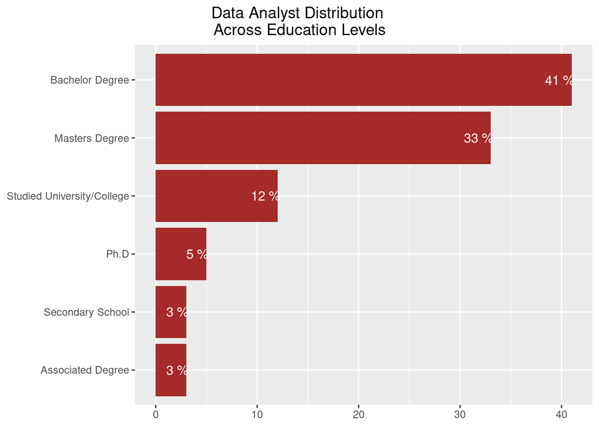

```r
education_2023[1,1] <- "Bachelor Degree"
education_2023[2,1] <- "Masters Degree"
education_2023[3,1]<- "Studied University/College"
education_2023[4,1] <- "Ph.D"
education_2023[5,1] <- "Associated Degree"
education_2023[6,1] <- "Secondary School"
education_2023$EdLevel <- factor(education_2023$EdLevel,                       levels = education_2023$EdLevel[order(education_2023$percent,            decreasing = FALSE)])
education_2023<-education_2023[-c(7:8),] # Remove last two insignificant levels
ggplot(data=education_2023, aes(x=EdLevel, y=percent)) +
  geom_bar(stat="identity",fill="brown") +
  coord_flip()+
  geom_text(aes(label = paste(percent,"%")), vjust = 0.5, hjust=0.9, colour = "white") +
  labs(title="Data Analyst Distribution \nAcross Education Levels") +
  theme(axis.title.x = element_blank(),
  axis.title.y = element_blank())+
  theme(plot.title.position = 'plot',
      plot.title = element_text(hjust = 0.5))
```

Back to Top

## Age Distribution

64% of the Data Analysts are in the age range of 25 to 44 years.

```r
age_2023<-df_2023 %>%
  drop_na(Age) %>%
  filter(DevType=="Data or business analyst") %>%
  group_by(Age) %>%
  summarize(count=n()) %>%
  mutate(percent = round(count / sum(count)*100, 0)) %>%
  arrange(desc(percent))
```

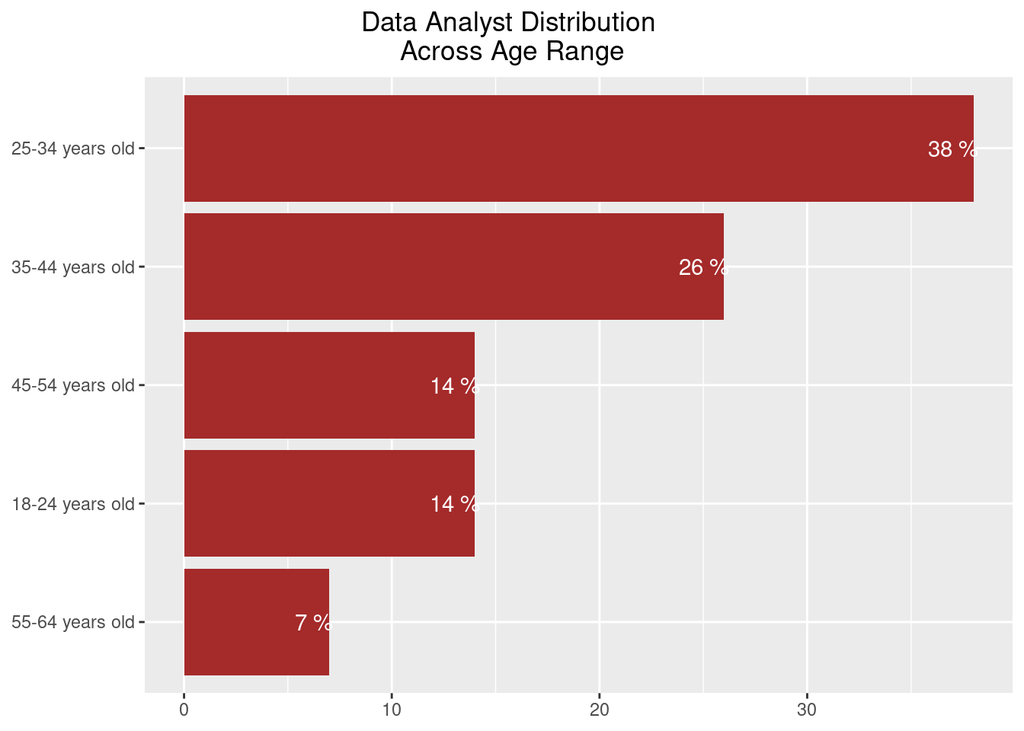

```r
age_2023$Age <- factor(age_2023$Age,
                  levels = age_2023$Age[order(age_2023$percent, decreasing = FALSE)])
age_2023<-age_2023[-c(6:7),] # Remove the least significant age ranges
ggplot(data=age_2023, aes(x=Age, y=percent)) +
  geom_bar(stat="identity",fill="brown") +
  coord_flip()+
  geom_text(aes(label = paste(percent,"%")), vjust = 0.5,hjust=0.9, colour = "white") +
  labs(title="Data Analyst Distribution \nAcross Age Range") +
  theme(axis.title.x = element_blank(),
  axis.title.y = element_blank())+
  theme(plot.title.position = 'plot',
      plot.title = element_text(hjust = 0.5))
```

Back to Top

## Coding Experience

More the 46% of Data Analysts have a coding experience of less than 10 years.

```r
df_2023$YearsCode<-as.integer(df_2023$YearsCode)
df_2023$Years[df_2023$YearsCode<=9] <- "1 to 9 Years"
df_2023$Years[(df_2023$YearsCode<=19)&(df_2023$YearsCode>=10)] <- "10 to 19 Years"
df_2023$Years[(df_2023$YearsCode<=29)&(df_2023$YearsCode>=20)] <- "20 to 29 Years"
df_2023$Years[(df_2023$YearsCode<=39)&(df_2023$YearsCode>=30)] <- "30 to 39 Years"
df_2023$Years[df_2023$YearsCode>=40] <- "More than 40 Years"
```

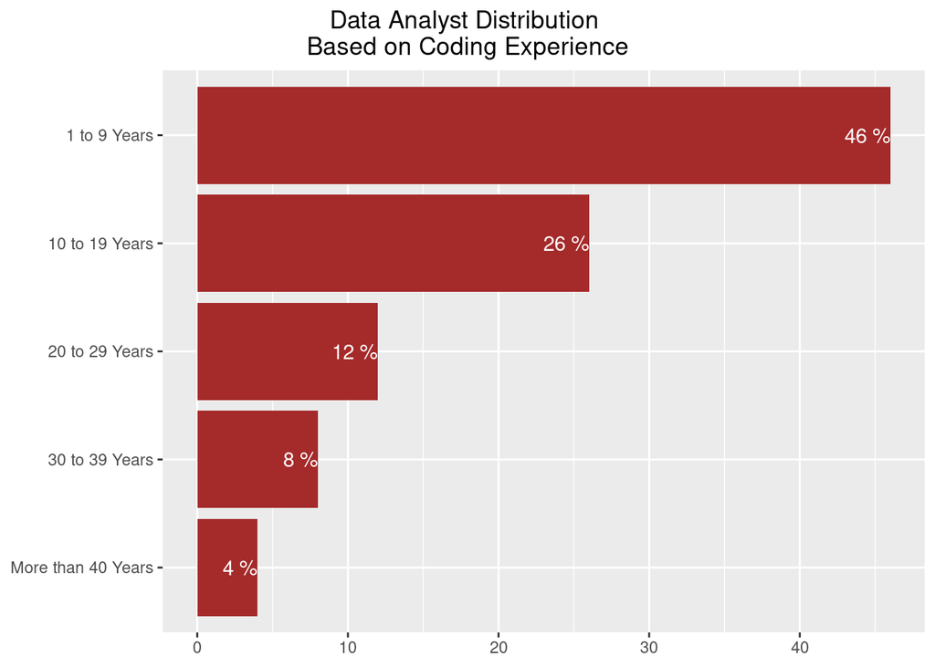

```r
years_2023<-df_2023 %>%
  filter(DevType=="Data or business analyst") %>%
  group_by(Years) %>%
  summarize(count=n()) %>%
  mutate(percent = round(count / sum(count)*100, 0)) %>%
  arrange(desc(percent))
years_2023$Years <- factor(years_2023$Years,
                  levels = years_2023$Years[order(years_2023$percent, decreasing = FALSE)])
#years_2023<-subset(years_2023,!is.nan(Years))
years_2023<-years_2023[-c(6),]
ggplot(data=years_2023, aes(x=Years, y=percent)) +
  geom_bar(stat="identity",fill="brown") +
  coord_flip()+
  geom_text(aes(label = paste(percent,"%")), vjust = 0.5,hjust=1.0, colour = "white")+
  labs(title="Data Analyst Distribution \nBased on Coding Experience") +
  theme(axis.title.x = element_blank(),
  axis.title.y = element_blank())+
  theme(plot.title.position = 'plot',
      plot.title = element_text(hjust = 0.5))
```

Back to Top

## Working Environment

More than half (51%) of the Data Analysts still woking in a hybrid working environment.

```r
remote_2023<-df_2023 %>%
  drop_na(RemoteWork) %>%
  filter(DevType=="Data or business analyst") %>%
  group_by(RemoteWork) %>%
  summarize(count=n()) %>%
  mutate(percent = round(count / sum(count)*100, 0)) %>%
  arrange(desc(percent))
remote_2023[1,1]<-"Hybrid"
remote_2023$RemoteWork <- factor(remote_2023$RemoteWork,
                  levels = remote_2023$RemoteWork[order(remote_2023$percent, decreasing = FALSE)])
remote_2023<-remote_2023[-c(4),]
```

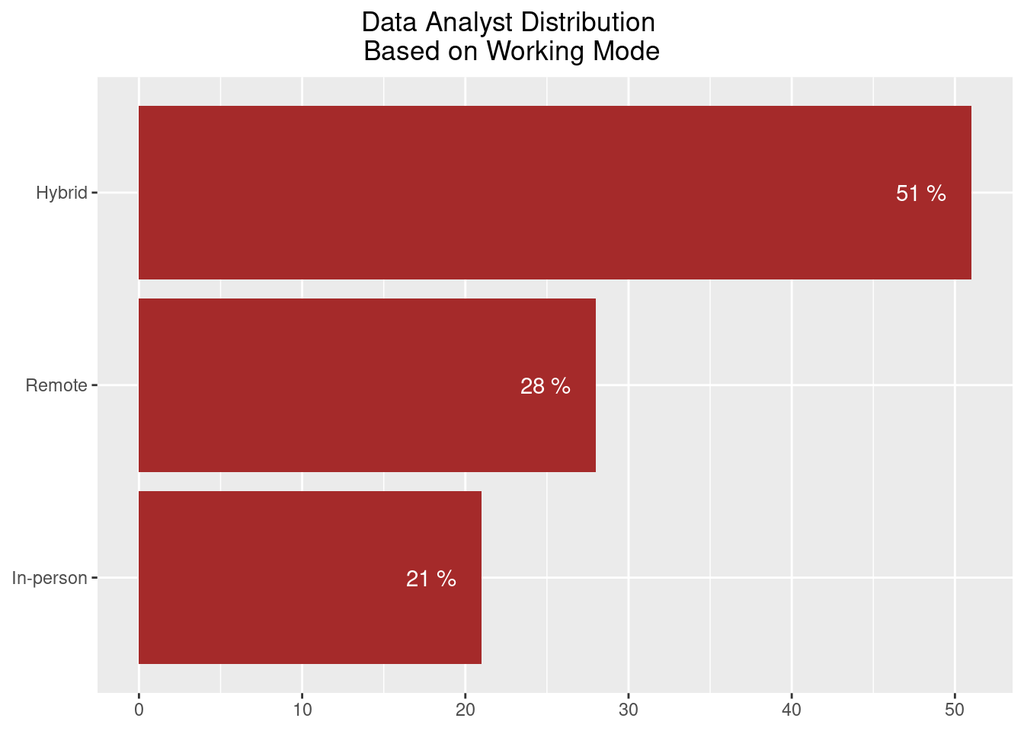

```r
ggplot(data=remote_2023, aes(x=RemoteWork, y=percent)) +
  geom_bar(stat="identity",fill="brown") +
  coord_flip()+
  geom_text(aes(label = paste(percent,"%")), vjust = 0.5,hjust=1.5, colour = "white") +
  labs(title="Data Analyst Distribution \nBased on Working Mode") +
  theme(axis.title.x = element_blank(),
  axis.title.y = element_blank())+
  theme(plot.title.position = 'plot',
      plot.title = element_text(hjust = 0.5))
```

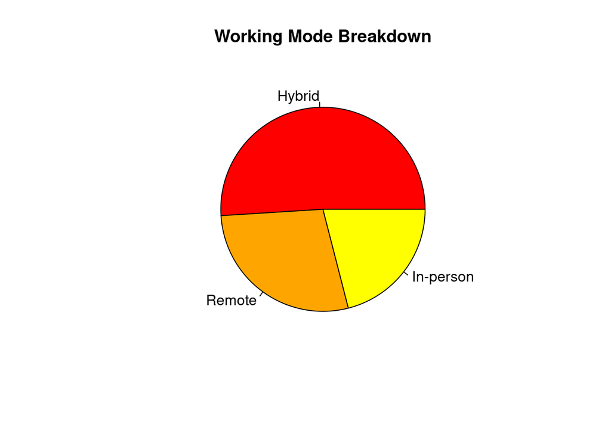

```r
result <- pie(remote_2023$percent,
  main = "Working Mode Breakdown",
  labels = c("Hybrid", "Remote", "In-person"),
  col = c("red", "orange", "yellow")
)
```

```r
print(result)
```

Back to Top

## Skills in Demand

SQL (73%) is the most used programming language among Data Analyst, followed by Python (68%) and R (27%).

```r
count_python=0
count_r=0
count_sql=0
#languages3=c("Python","R","SQL")
language_2023<-df_2023 %>%
  drop_na(LanguageHaveWorkedWith) %>%
  select(DevType,LanguageHaveWorkedWith) %>%
  filter(DevType=="Data or business analyst")
col="LanguageHaveWorkedWith"
i<-0
for (row in 1:nrow(language_2023)){
  cell<-language_2023[row,col]
  if (is.na(cell)){
    next
  }
  #print(cell)
  #print(strsplit(as.character(cell),';',fixed=TRUE))
  for (value in strsplit(as.character(cell),';',fixed=TRUE)[[1]]){
    if (value=="Python"){
      count_python=count_python+1
      #print(count_python)
    }
    if(value=="R"){
      count_r=count_r+1
    }
    if(value=="SQL"){
      count_sql=count_sql+1
    }

  }
}
count_python<-count_python/nrow(language_2023)*100
count_r<-count_r/nrow(language_2023)*100
count_sql<-count_sql/nrow(language_2023)*100

programming<-c("Pyhon","R","SQL")
percent<-as.integer(c(count_python,count_r,count_sql))
programming_2023<-data.frame(programming,percent)
programming_2023
```

```
##   programming percent
## 1       Pyhon      68
## 2           R      27
## 3         SQL      73
```

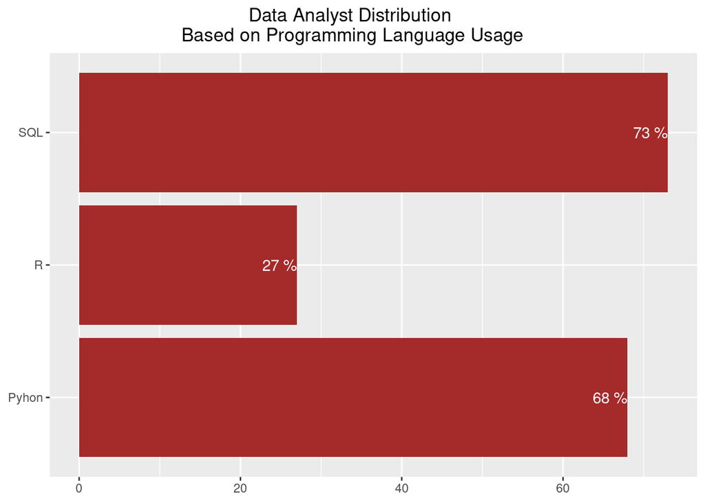

```r
ggplot(data=programming_2023, aes(x=programming, y=percent)) +
  geom_bar(stat="identity",fill="brown") +
  coord_flip()+
  geom_text(aes(label = paste(percent,"%")), vjust = 0.5,hjust=1.0, colour = "white")+
  labs(title="Data Analyst Distribution \nBased on Programming Language Usage") +
  theme(axis.title.x = element_blank(),
  axis.title.y = element_blank())+
  theme(plot.title.position = 'plot',
      plot.title = element_text(hjust = 0.5))
```

Back to Top

## Geographic Distribution

More than a quarter (28%) of Data Analyst are from USA.

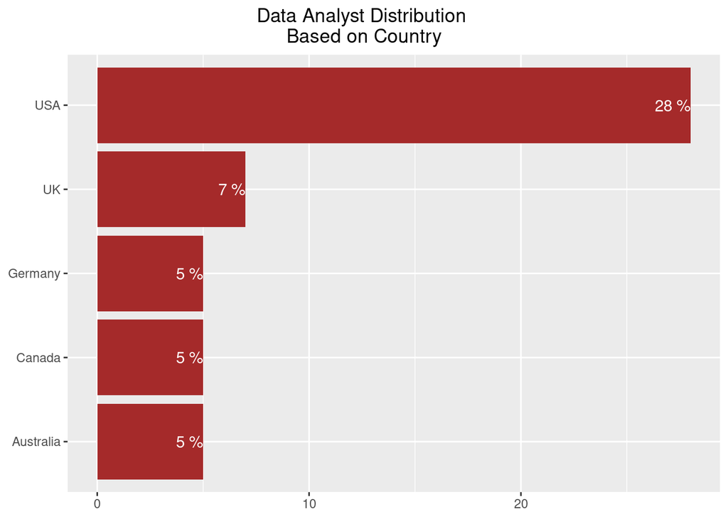

```r
country_2023<-df_2023 %>%
  drop_na(Country) %>%
  filter(DevType=="Data or business analyst") %>%
  group_by(Country) %>%
  summarize(count=n()) %>%
  mutate(percent = round(count / sum(count)*100, 0)) %>%
  arrange(desc(percent))
country_2023$Country <- factor(country_2023$Country,
                  levels = country_2023$Country[order(country_2023$percent, decreasing = FALSE)])
#years_2023<-subset(years_2023,!is.nan(Years))
country_2023<-country_2023[c(1:5), ]
#country_2023[1,1]<-"USA"
#country_2023[2,1]<-"UK"
country=c("USA","UK","Germany","Canada","Australia")
ggplot(data=country_2023, aes(x=country, y=percent)) +
  geom_bar(stat="identity",fill="brown") +
  coord_flip()+
  geom_text(aes(label = paste(percent,"%")), vjust = 0.5,hjust=1.0, colour = "white")+
  labs(title="Data Analyst Distribution \nBased on Country") +
  theme(axis.title.x = element_blank(),
  axis.title.y = element_blank())+
  theme(plot.title.position = 'plot',
      plot.title = element_text(hjust = 0.5))
```

Back to Top

## Salary Distribution across Industries, Regions and Experience Levels

In Canada, data analysts working in Finacial Institutes get the highest salary.

Salary in log scale has a linear relationship with work experience levels.

In Oil and Gas Industry, the salaries of Data Analysts have a wide range.

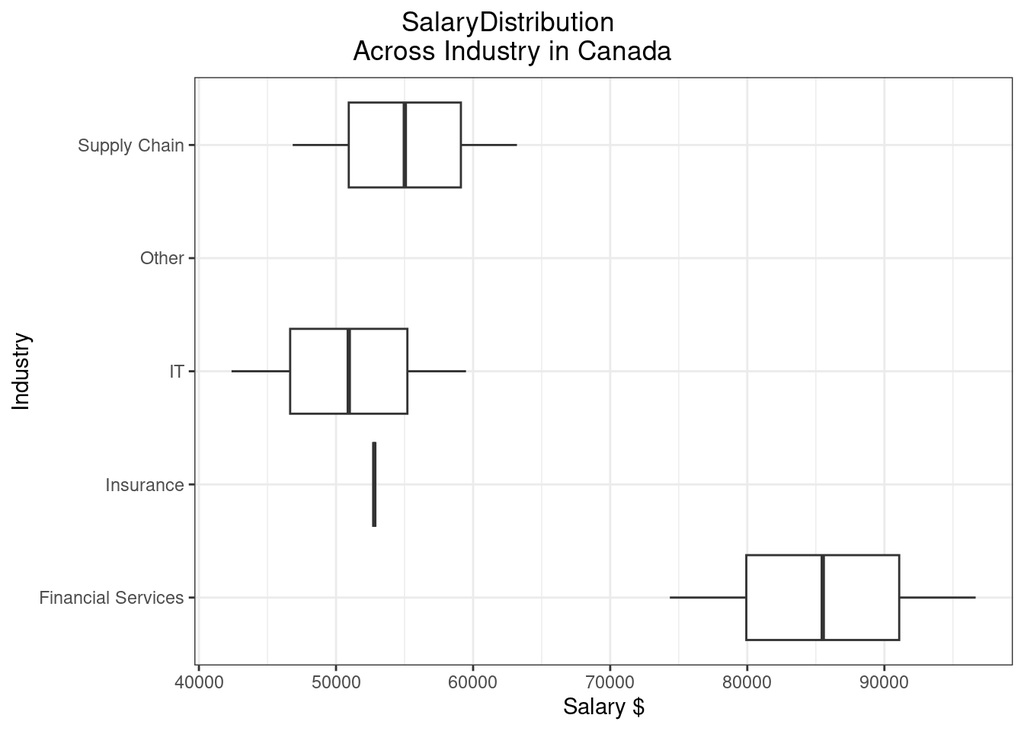

```r
salary_2023<-df_2023 %>%
  drop_na(Industry) %>%
  filter(DevType=="Data or business analyst",Country=="Canada")
salary_2023$Industry[salary_2023$Industry=="Manufacturing, Transportation, or Supply Chain"]="Supply Chain"

salary_2023$Industry[salary_2023$Industry=="Information Services, IT, Software Development, or other Technology"]="IT"
salary_2023 %>%
  drop_na(Industry) %>%
  ggplot(aes(x=Industry,y=ConvertedCompYearly) )+
  geom_boxplot()+
  coord_flip() +
  theme_bw() +
  labs(title="SalaryDistribution \nAcross Industry in Canada",x="Industry",y="Salary $")+
  theme(plot.title.position = 'plot',
      plot.title = element_text(hjust = 0.5))
```

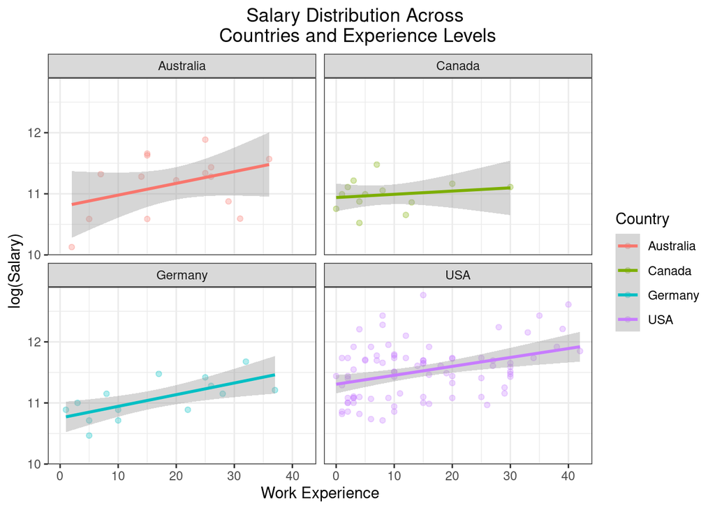

```r
df_2023$Country[df_2023$Country=="United States of America"]="USA"
df_2023 %>%
  drop_na(WorkExp) %>%
  drop_na(ConvertedCompYearly) %>%
  filter(Country %in% c("USA","Canada","Germany","Australia"),DevType=="Data or business analyst") %>%
  ggplot(aes(x=WorkExp,y=log(ConvertedCompYearly),col=Country))+
  geom_point(alpha=0.3)+
  geom_smooth(method=lm)+
  facet_wrap(~Country)+
  theme_bw() +
  labs(title="Salary Distribution Across \nCountries and Experience Levels",x="Work Experience",y="log(Salary)")+
  theme(plot.title.position = 'plot',
      plot.title = element_text(hjust = 0.5))
```

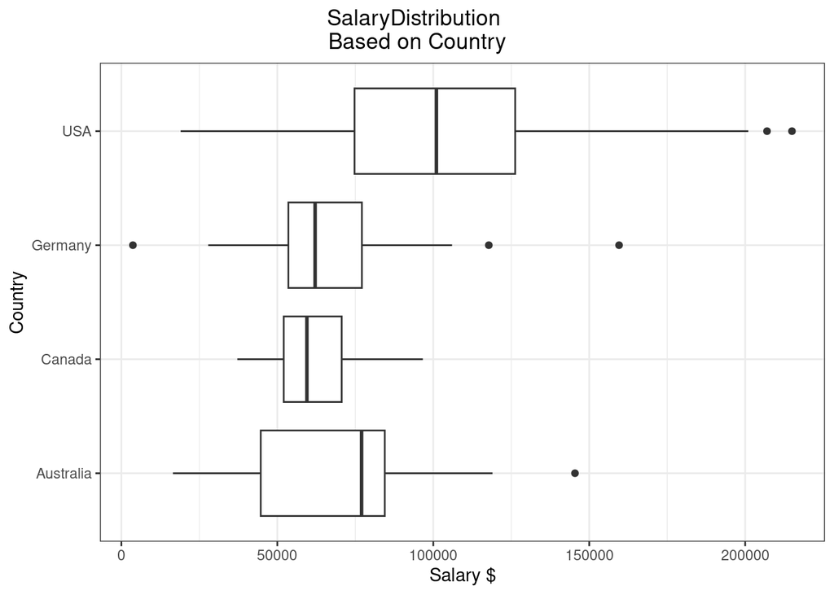

```r
salary_2<-df_2023 %>%
  filter(DevType=="Data or business analyst",Country %in% c("Canada","USA","Australia","Germany"))



salary_2 %>%
  filter(ConvertedCompYearly<250000) %>%
  ggplot(aes(x=Country,y=ConvertedCompYearly) )+
  geom_boxplot()+
  coord_flip() +
  theme_bw() +
  labs(title="SalaryDistribution \nBased on Country",x="Country",y="Salary $")+
  theme(plot.title.position = 'plot',
      plot.title = element_text(hjust = 0.5))
```

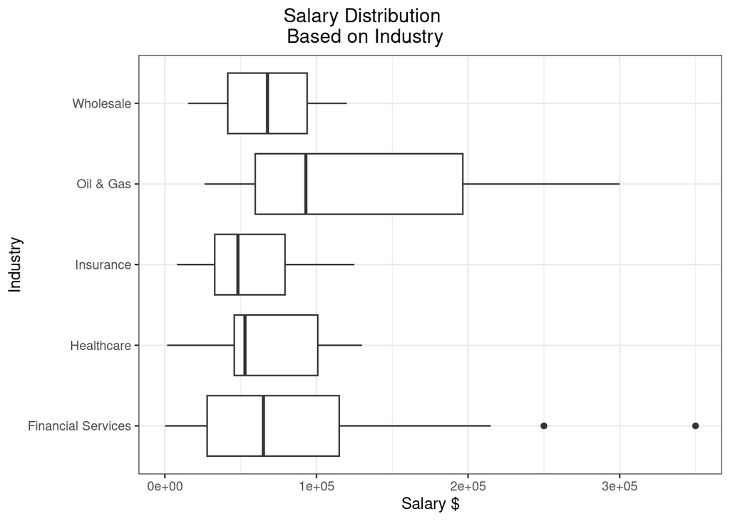

```r
df_2023 %>%
  drop_na(Industry) %>%
  filter (Industry %in% c("Wholesale","Oil & Gas","Insurance","Healthcare","Financial Services"),DevType=="Data or business analyst") %>%
  ggplot(aes(Industry,ConvertedCompYearly))+
  geom_boxplot()+
  coord_flip()+
  theme_bw() +
  labs(title="Salary Distribution \nBased on Industry",x="Industry",y="Salary $")+
  theme(plot.title.position = 'plot',
      plot.title = element_text(hjust = 0.5))
```

Back to Top

## t-test: Is there a difference in mean salary between USA and Canada?

According to the two sided t-test, there is significant difference in mean salary of Data Analyst between USA (Mean Salary: $ 116500 ) and Canada (Mean Salary: $ 75631 ).

```r
df_2023 %>%
  filter(Country %in% c("USA","Canada"),DevType=="Data or business analyst") %>%
  t.test(ConvertedCompYearly~Country,data=.,
         alternative="two.sided")
```

```
##
##  Welch Two Sample t-test
##
## data:  ConvertedCompYearly by Country
## t = -2.8292, df = 22.068, p-value = 0.009747
## alternative hypothesis: true difference in means between group Canada and group USA is not equal to 0
## 95 percent confidence interval:
##  -70820.32 -10915.96
## sample estimates:
## mean in group Canada    mean in group USA
##             75631.89            116500.03
```

Back to Top